# Regresja i analiza wariancji - Sprawozdanie 2

Analiza wariancji - sprawozdanie

Adrian Kowalski

Politechnika Krakowska

# Zadanie 1

## Treść:

Zarząd firmy “Firma na A”, która zajmuje się, między innymi sprzedażą telefonów komórkowych zastanawia się nad zmianą szaty graficznej strony, na której można dokonać zakupu ich flagowego smartfona. Przygotowali dwie nowe szaty graficzne dla strony, jedna z dużym, prostokątnym, czerwonym guzikiem “kup teraz”, druga z dużym, okrągłym, srebrnym guzikiem kup teraz. Za pomocą standardowej metodologii testu A/B/C kierowali z jednakowym prawdopodobieństwem nowych użytkowników na jedną z 3 stron. Przez 30 dni mierzyli co 6 godzin ilość sprzedanych sztuk smartfona dla każdej z wersji. Waszym zadaniem jest zbadanie za pomocą poznanych metod (analizy wariancji i jej różnych modyfikacji) odpowiedź na pytanie, czy nowe szaty graficzne miały wpływ na sprzedaż, a jeśli tak to która z szat jest najlepsza.

## Opis danych:

version - 1 - stara, 2 - prostokąt, 3 - kółko

sales - ilość sprzedanych sztuk

## Rozwiązanie:

Wprowadźmy nasze dane z pliku:

```r
sites <- readr::read_csv('zadanie1.csv')
head(sites)
```

| version | sales |
| --- | --- |
| 1 | 295 |
| 1 | 115 |
| 1 | 201 |
| 1 | 251 |
| 1 | 237 |
| 1 | 320 |

Odpowiedź na nasze pytanie kryje się, czy któraś szata graficzna strony jest lepsza od innych (pod względem ilości sprzedanych sztuk telefonów) oraz wskazanie jej. Zatem najpierw powinniśmy nasze dane podzielić względem wersji, jakie mamy dostępne:

```r
sites_ver1 <- sites %>% filter(version == 1)
sites_ver2 <- sites %>% filter(version == 2)
sites_ver3 <- sites %>% filter(version == 3)
sites_ver1
```

| version | sales |
| --- | --- |
| 1 | 295 |
| 1 | 115 |
| 1 | 201 |
| 1 | 251 |
| 1 | 237 |
| 1 | 320 |
| 1 | 254 |
| 1 | 228 |
| 1 | 168 |
| 1 | 225 |

[output cut: 170 more lines]

```r
sites_ver2
```

| version | sales |
| --- | --- |
| 2 | 243 |
| 2 | 248 |
| 2 | 246 |
| 2 | 130 |
| 2 | 270 |
| 2 | 192 |
| 2 | 216 |
| 2 | 247 |
| 2 | 90 |
| 2 | 161 |

[output cut: 170 more lines]

```r
sites_ver3
```

| version | sales |
| --- | --- |
| 3 | 231 |
| 3 | 142 |
| 3 | 174 |
| 3 | 113 |
| 3 | 177 |
| 3 | 160 |
| 3 | 158 |
| 3 | 211 |
| 3 | 315 |
| 3 | 228 |

[output cut: 170 more lines]

### Jednoczynnikowa Analiza Wariancji:

Za pomocą metody jednoczynnikowej analizy wariancji poznamy, czy jakaś szata graficzna odstaje od reszty i wpływa na sprzedaż telefonów. Ponieważ wersji naszej strony jest więcej niż dwie, nie możemy skorzystać z testu t studenta, który tworzy hipotezę dla dwóch niezależnych prób. Na szczęście jeżeli mamy więcej grup, to mamy narzędzie do weryfikacji różnicy w średnich między tymi grupami. W klasycznej analizie wariancji zakładamy, że wariancja każdej z grup jest równa pewnej, jednakowej stałej. Do analizy wariancji używamy statystyki testowej $F$, która ma rozkład zwany rozkładem Snedecora-Fischera.

Przy analizie wariancji zakładamy, że mamy próby pochodzące z $k$ grup $x_1,x_2,..., x_k$ o średnich $\mu_1, \mu_2,..., \mu_k$. Hipotezy naszego testu wyglądają następująco:

$$H_0: \mu_1=\mu_2=...=\mu_k$$
$$H_1: \text{Przynajmniej jedna ze średnich
}\mu_i\text{ jest różna od pozostałych.}$$

Aby wyprowadzić statystykę testową użyjemy zwyczajowej notacji. $y_{ij}$ będzie oznaczało $j$-tą obserwację z $i$-tej grupy, $\overline{y}$ średnią bez podziału na grupy, a $\overline{y}_i$ średnią $i$-tej grupy. Wtedy **zakładamy**, że $y_{ij} = \overline{y} + (\overline{y}_i - \overline{y}) + (y_{ij} - \overline{y}_i)$, czyli że możemy rozłożyć obserwację na $3$ składniki: średnią wszystkich obserwacji, odchylenie średniej w grupie od całkowitej średniej i odchylenie obserwacji od średniej w grupie (wrócimy do tego założenia później). Chcemy też rozbić całkowitą sumę kwadratów
$$SST = \sum_{i,j} (y_{ij} - \overline{y})^2 =
\sum_{i,j} y_{ij}^2 - \left( \sum_{i,j} y_{ij} \right)^2,$$
gdzie sumujemy po wszystkich $i$ - grupach i wszystkich $j$ - obserwacjach w grupach na sumę kwadrtów pomiędzy grupami $SSA$ i sumę kwadratów wewnątrz grup $SSW$.

Sumę kwadratów pomiędzy grupami wyznaczamy jako:
$$SSA = \sum_{i=1}^k n_i(\overline{y}_i -
\overline{y})^2,$$
gdzie $n_i$ to liczność $i$-tej grupy.

Sumę kwadratów wewnątrz grup wyznaczamy jako:
$$SSW = \sum_{i,j} (y_{ij} - \overline{y}_i)^2.$$

To pozwala nam zdefiniować średnią sumę kwadratów pomiędzy grupami $MSA = \frac{SSA}{k-1}$ i średnią sumę kwadratów wewnątrz grup $MSW= \frac{SSW}{n - k}$.

Wtedy nasza statystyka testowa $F$ (przy założeniu $H_0$) ma postać:
$$F = \frac{MSA}{MSW} =
\frac{\frac{\sum_{i=1}^k n_i(\overline{y}_i -
\overline{y})^2}{k-1}}{\frac{\sum_{i,j} (y_{ij} -
\overline{y}_i)^2}{n-k}}.$$

Powyższa statystyka ma rozkład $F$ z parametrami $df_1 = k -1$, $df_2 = n - k$. Za jej pomocą uda nam się poznać, czy wszystkie średnie są takie same według hipotezy zerowej.

Najpierw obliczmy poszczególne statystyki:

```r
k <- 3
n <- length(sites$sales)
```

```r
mean <- mean(sites$sales)
# Obliczenia dla version = 1
mean_ver1 <- mean(sites_ver1$sales)
SSA_ver1 <- sum(nrow(sites_ver1) * (mean_ver1 - mean(sites$sales))^2)
SSW_ver1 <- sum((sites_ver1$sales - mean_ver1)^2)

# Obliczenia dla version = 2
mean_ver2 <- mean(sites_ver2$sales)
SSA_ver2 <- sum(nrow(sites_ver2) * (mean_ver2 - mean(sites$sales))^2)
SSW_ver2 <- sum((sites_ver2$sales - mean_ver2)^2)

# Obliczenia dla version = 3
mean_ver3 <- mean(sites_ver3$sales)
SSA_ver3 <- sum(nrow(sites_ver3) * (mean_ver3 - mean(sites$sales))^2)
SSW_ver3 <- sum((sites_ver3$sales - mean_ver3)^2)

# Suma globalna
SSA <- SSA_ver1 + SSA_ver2 + SSA_ver3
SSW <- SSW_ver1 + SSW_ver2 + SSW_ver3

MSA <- SSA / (k-1)
MSW <- SSW / (n-k)

# Statystyka F
F_statistic <- MSA / MSW
```

```r
cat("SSA:", SSA, "\n","SSW:", SSW, "\n","MSA:", MSA, "\n","MSW:", MSW, "\n")
```

```
## SSA: 60968.05
##  SSW: 1470699
##  MSA: 30484.02
##  MSW: 2738.732
```

```r
cat("F-statistic:", F_statistic, "\n")
```

```
## F-statistic: 11.13071
```

Zbudujmy teraz model ANOWA za pomocą $summary(aov(...))$, aby porównać średnie wyniki w zależności od wersji szaty graficznej strony (porównując również nasze obliczenia):

```r
model_aov <- aov(sales ~ version, data = sites)
summary(model_aov)
```

```
##              Df  Sum Sq Mean Sq F value Pr(>F)
## version       1     548   547.6   0.192  0.661
## Residuals   538 1531120  2845.9
```

Zauważmy, że w powyższym podsumowaniu mamy tylko 1 stopień swobody przy zmiennej $version$.

```r
sites1 <- sites %>% dplyr::mutate(version = as.character(version))
```

Buduje ponownie model:

```r
model_aov <- aov(sales ~ version, data = sites1)
summary(model_aov)
```

```
##              Df  Sum Sq Mean Sq F value   Pr(>F)
## version       2   60968   30484   11.13 1.83e-05 ***
## Residuals   537 1470699    2739
## ---
## Signif. codes:  0 '***' 0.001 '**' 0.01 '*' 0.05 '.' 0.1 ' ' 1
```

Zauważamy, że poszczególne statystyki są identyczne z tymi, które obliczyliśmy. Zatem nasze obliczenia się zgadzają zgodnie z modelem ANOVA wbudowanym w R. Widzimy, że $p-value < 0.05$ zatem odrzucamy hipoteze zerową. Istnieje wersja, która odstaje od reszty. Jednak dalej za pomocą ANOVA nie damy rady się dowiedzieć, która z nich jest. Spójrzmy na wykres punktowy oraz pudełkowy sprzedaży telefonów w zależności od wersji szaty graicznej:

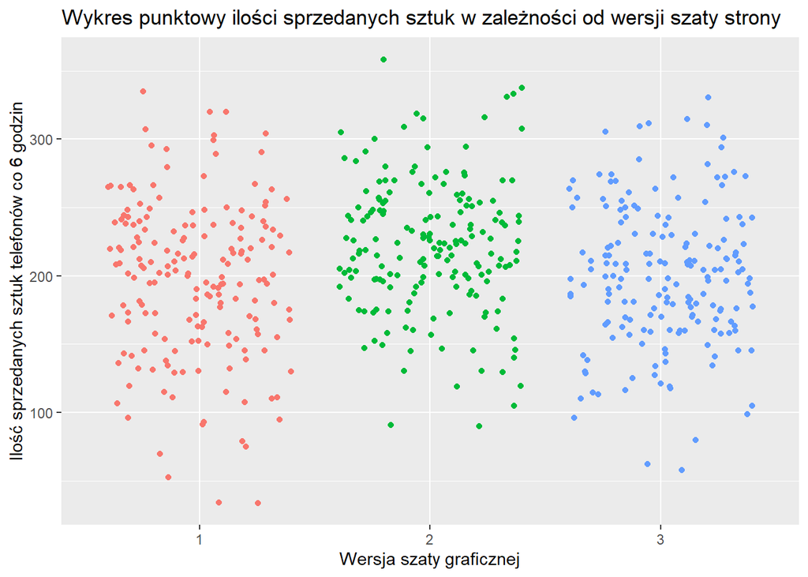

```r
ggplot(sites1, aes(x=version, y=sales)) + geom_point(aes(color=version), position='jitter') + labs(title = 'Wykres punktowy ilości sprzedanych sztuk w zależności od wersji szaty strony', x='Wersja szaty graficznej', y='Ilość sprzedanych sztuk telefonów co 6 godzin') + theme(legend.position = 'none')
```

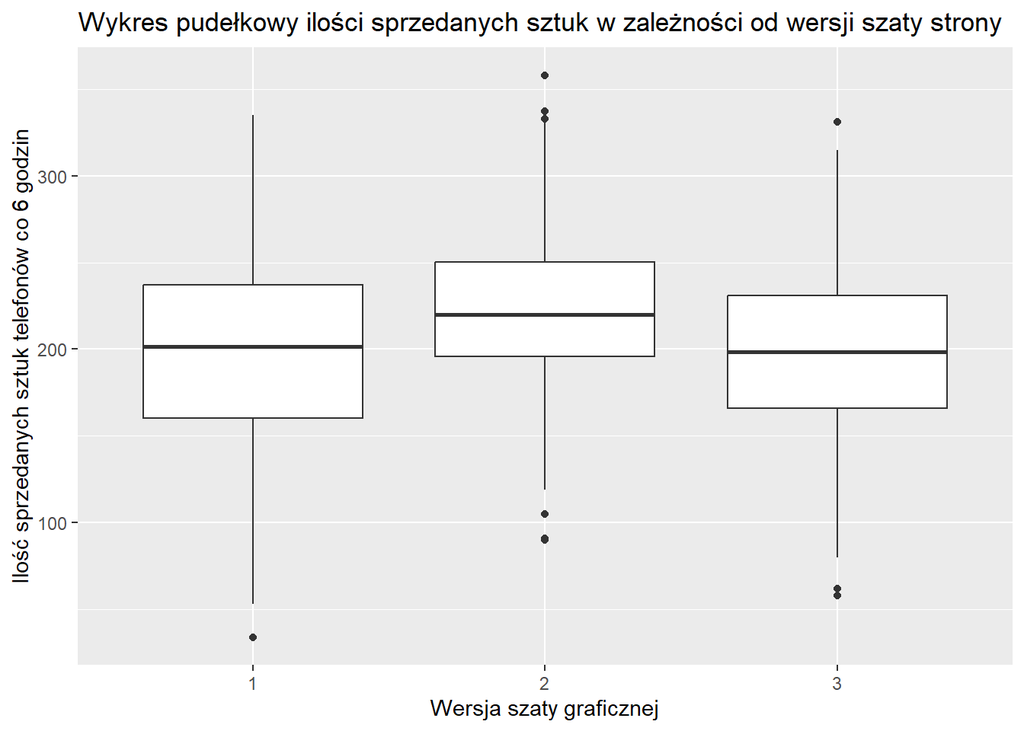

```r
ggplot(sites1, aes(x=version, y=sales)) + geom_boxplot() + labs(title = "Wykres pudełkowy ilości sprzedanych sztuk w zależności od wersji szaty strony", x='Wersja szaty graficznej', y='Ilość sprzedanych sztuk telefonów co 6 godzin')
```

Możemy spekulować na sposób graiczny, że $version = 2$ jest najlepszym kandydatem, który miał najwiekszy wpływ na sprzedaż pod względem ilościowym (wykres punktowy) jak i zakresem większości wartości sprzedaży (wykres pudełkowy). Spójrzmy na poszczególne kwartyle wersji:

```r
qver1 <- quantiles_ver1 <- quantile(sites_ver1$sales)
qver2 <- quantiles_ver2 <- quantile(sites_ver2$sales)
qver3 <- quantiles_ver3 <- quantile(sites_ver3$sales)
qver1
```

```
##     0%    25%    50%    75%   100%
##  34.00 160.25 201.50 237.00 335.00
```

```r
qver2
```

```
##     0%    25%    50%    75%   100%
##  90.00 195.75 220.00 250.25 358.00
```

```r
qver3
```

```
##    0%   25%   50%   75%  100%
##  58.0 166.0 198.5 231.0 331.0
```

Widzimy, że zarazem $min$ jak i $max$ jest większe zdecydowanie dla $version = 2$. Popatrzmy również na średnie oraz ilość sprzedanych telefonów dla podanej wersji:

```r
means <- c(mean_ver1,mean_ver2,mean_ver3)
phone_sales <- c(sum(sites_ver1$sales), sum(sites_ver2$sales), sum(sites_ver3$sales))
means
```

```
## [1] 197.0444 220.7167 199.5111
```

```r
phone_sales
```

```
## [1] 35468 39729 35912
```

Średnia dla $version = 2$ jak i ilość sprzedanych telefonów jest zdecydowanie większa od dwóch pozostałych. Można również spojrzeć po naszej analizie “na oko”, że $version =1$ oraz $version = 3$ mają zbliżone wartości sprzedaży.

### Analiza Tuckeya-Kramera:

Wrócmy teraz do naszego ostatniego pytania: która szata graficzna jest najlepsza? Mamy narzędzie, które pomoże nam po odrzuceniu hipotezy zerowej analizy wariancji. Tym narzędziem jest procedura Tukeya-Kramera:

```r
Tukey <- TukeyHSD(aov(sales ~ version, data = sites1))
Tukey
```

```
##   Tukey multiple comparisons of means
##     95% family-wise confidence level
##
## Fit: aov(formula = sales ~ version, data = sites1)
##
## $version
##           diff       lwr       upr     p adj
## 2-1  23.672222  10.70749 36.636953 0.0000625
## 3-1   2.466667 -10.49806 15.431398 0.8956845
## 3-2 -21.205556 -34.17029 -8.240825 0.0003977
```

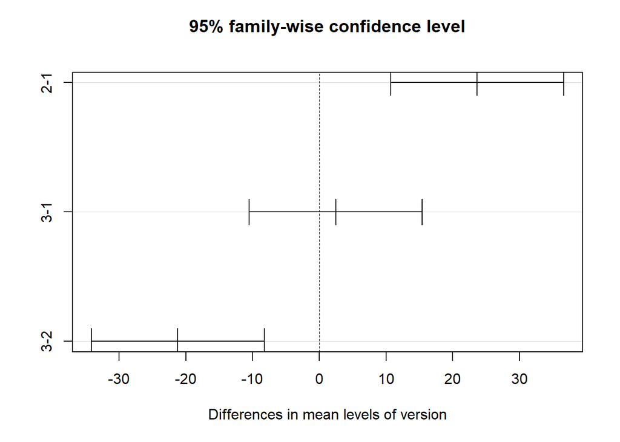

```r
plot(Tukey)
```

Możemy zobaczyć tak jak wcześniej zauważyliśmy “na oko”, że róznica między $3-1$ jest bardzo mała, nieznacząca co potwierdza również $p\_adj > 0.05$, które na tak wysokim poziomie mówi nam, że nie istnieje znacząca róznica między $version = 1$ a $version = 3$ (co potwierdza również wykres). Natomiast w pozostałych dwóch przypadkach, gdzie wystepuje $version = 2$ nasze $p\_adj < 0.05$ co potwierdza nasze przypuszczenia, że jej średnia populacji nie jest równa jak dla reszty. Możemy również zauważyć, że róznica średnich równa 0 nie znajduję się w 95% przedziale ufności dla grupy $3-2$ oraz $2-1$.

Spoglądając na nasze wcześniejsze statystyki dotyczące średniej, która dla $version = 2$ była znacząca większa od reszty, możemy potwierdzić, że wersja druga szaty graficznej z dużym, prostokątnym, czerwonym guzikiem “kup teraz” jest najlepsza, ponieważ miała największy wpływ na sprzedaż telefonów.

## Założenia dla ANOVA:

1. Każdą z obserwacji można rozłożyć na 3 składniki: średnią wszystkich obserwacji, odchylenie średniej w grupie od całkowitej średniej i odchylenie obserwacji od średniej w grupie podane za pomocą wzoru: $y_{ij} = \overline{y} + (\overline{y}_i - \overline{y}) + (y_{ij} - \overline{y}_i)$.

Stwórzmy funkcje, która będzie obliczała podany wynik dla każdej obserwacji:

```r
assump_yij_formula <- function(y, version) {
  y_mean <- mean(y)
  y_i_mean <- tapply(y, version, mean)
  y_ij_formula <- y_mean + (y_i_mean[version] - y_mean) + (y - y_i_mean[version])
  return(y_ij_formula)
}
```

Stwórzmy nową tabelę, która będzie miała dodatkową kolumnę z obliczonym wynikiem dla każdej obserwacji:

```r
sites1$y_ij_formula <- assump_yij_formula(sites1$sales, sites1$version)
print(sites1)
```

```
## # A tibble: 540 × 3
##    version sales y_ij_formula
##    <chr>   <dbl>    <dbl[1d]>
##  1 1         295          295
##  2 1         115          115
##  3 1         201          201
##  4 1         251          251
##  5 1         237          237
##  6 1         320          320
##  7 1         254          254
##  8 1         228          228
##  9 1         168          168
## 10 1         225          225
## # ℹ 530 more rows
```

Sprawdźmy czy podane wyniki zgadzają się dla każdej obserwacji:

```r
sites1$y_ij_formula <- as.numeric(sites1$y_ij_formula)
is_same <- all.equal(sites1$sales, sites1$y_ij_formula, check.attributes = FALSE, tolerance = 0.0001)
print(is_same)
```

```
## [1] TRUE
```

Zatem założenie zostało spełnione.

2. Całkowita suma kwadratów $SST = \sum_{i,j} (y_{ij} - \overline{y})^2 = \sum_{i,j} y_{ij}^2 - \left( \sum_{i,j} y_{ij} \right)^2$, gdzie sumujemy po wszystkich $i$ - grupach i wszystkich $j$ - obserwacjach w grupach, na sumę kwadrtów pomiędzy grupami $SSA$ i sumę kwadratów wewnątrz grup $SSW$.

```r
SST <- sum((sites1$sales - mean(sites1$sales))^2)
SST
```

```
## [1] 1531667
```

```r
SST2 <- SSA + SSW
SST2
```

```
## [1] 1531667
```

Poniższe obliczenia są poprawne, zatem założenie również jest spełnione.

# Zadanie 2

## Treść:

Po waszym sukcesie dotyczącym wyboru szaty graficznej strony, zarząd “Firmy na A” postawił was przed kolejnym, trudniejszym zadaniem. Kolejną z branży, którą zajmuje się firma jest streaming video w internecie. Inżynierowie firmy stworzyli nową funkcjonalność autoodtwarzania, która ich zdaniem ma zwiększyć czas oglądania wideo podczas jednej sesji przez konkretnego użytkownika, a co za tym idzie zwiększyć przychody firmy z reklam. Ich zdaniem ta funkcjonalność szczególnie będzie działała na dzieci. Ponownie za pomocą metdologii testu A/B kierowali użytkowników z jednakowym prawdopodobieństwem na wersje strony z nowym odtwarzaczem lub ze starym. Za pomocą dwuczynnikowej analizy wariancji sprawdź, czy inżynierowie mieli racje.

## Opis danych:

group - 1 - użytkownicy poniżej 16 roku życia, 2 - użytkownicy powyżej 16 roku życia, ale poniżej 40-tego, 3 - użytkownicy powyżej 40 roku życia

version - 1 - wersja ze starym odtwarzaczem, 2 - wersja z nowym odtwarzaczem

time - czas w minutach spędzony na oglądaniu w danej sesji

## Rozwiązanie:

Najpierw wprowadźmy nasze dane do zadania:

```r
player <- readr::read_csv('zadanie2.csv')
head(player)
```

| group | time | version |
| --- | --- | --- |
| 1 | 65 | 1 |
| 1 | 60 | 2 |
| 1 | 53 | 1 |
| 1 | 65 | 1 |
| 1 | 64 | 1 |
| 1 | 65 | 1 |

Chcemy odpowiedź na stwierdzenie inżynierów: czy nowy sposób odtwarzania video będzie przynosił największe przychodzy (=czas oglądania) dla dzieci. Aby na to odpowiedzieć, przeprowadzimy dwuczynnikową analizę wariancji. Interesującymi dla nas zmiennymi są $time$, $group$ oraz $version$.

Zatem czas oglądania $time$ będzie zależał od dwóch czynników: $group$ i $version$.

Zmienna $group$ z opisu danych można podzielić na 3 kategorie osób a $version$ na 2.

Spójrzmy na poszczególne tabelki:

```r
player_group1 <- player %>% filter(group == 1)
player_group2 <- player %>% filter(group == 2)
player_group3 <- player %>% filter(group == 3)
player_group1
```

| group | time | version |
| --- | --- | --- |
| 1 | 65 | 1 |
| 1 | 60 | 2 |
| 1 | 53 | 1 |
| 1 | 65 | 1 |
| 1 | 64 | 1 |
| 1 | 65 | 1 |
| 1 | 64 | 2 |
| 1 | 59 | 1 |
| 1 | 58 | 1 |
| 1 | 63 | 1 |

[output cut: 490 more lines]

```r
player_group2
```

| group | time | version |
| --- | --- | --- |
| 2 | 16 | 2 |
| 2 | 23 | 1 |
| 2 | 27 | 1 |
| 2 | 18 | 1 |
| 2 | 22 | 2 |
| 2 | 20 | 1 |
| 2 | 30 | 2 |
| 2 | 21 | 1 |
| 2 | 22 | 1 |
| 2 | 21 | 1 |

[output cut: 390 more lines]

```r
player_group3
```

| group | time | version |
| --- | --- | --- |
| 3 | 25 | 1 |
| 3 | 29 | 2 |
| 3 | 20 | 1 |
| 3 | 16 | 2 |
| 3 | 17 | 1 |
| 3 | 25 | 2 |
| 3 | 24 | 1 |
| 3 | 22 | 2 |
| 3 | 20 | 1 |
| 3 | 25 | 2 |

[output cut: 290 more lines]

```r
player_version1 <- player %>% filter(version == 1)
player_version2 <- player %>% filter(version == 2)
player_version1
```

| group | time | version |
| --- | --- | --- |
| 1 | 65 | 1 |
| 1 | 53 | 1 |
| 1 | 65 | 1 |
| 1 | 64 | 1 |
| 1 | 65 | 1 |
| 1 | 59 | 1 |
| 1 | 58 | 1 |
| 1 | 63 | 1 |
| 1 | 61 | 1 |
| 1 | 64 | 1 |

[output cut: 606 more lines]

```r
player_version2
```

| group | time | version |
| --- | --- | --- |
| 1 | 60 | 2 |
| 1 | 64 | 2 |
| 1 | 60 | 2 |
| 1 | 67 | 2 |
| 1 | 58 | 2 |
| 1 | 62 | 2 |
| 1 | 64 | 2 |
| 1 | 57 | 2 |
| 1 | 62 | 2 |
| 1 | 60 | 2 |

[output cut: 574 more lines]

Zbadajmy teraz statystyki między poszczególnymi grupami.

```r
mean(player_group1$time)
```

```
## [1] 60.828
```

```r
mean(player_group2$time)
```

```
## [1] 20.765
```

```r
mean(player_group3$time)
```

```
## [1] 21.92667
```

```r
mean(player_version1$time)
```

```
## [1] 37.56656
```

```r
mean(player_version2$time)
```

```
## [1] 37.94007
```

Widzimy, że występują różne średnie w grupach, natomiast w wersjach są prawie identyczne. Nie jesteśmy jednak pewni co się dzieję w przypadku, gdy połączymy grupy razem z wersjami. Zastosujemy dwuczynnikową analize wariancji, aby wskazać, czy konkretna grupa odstaje od reszty i czy zależy od danej wersji.

### Model:

Stwórzmy model dla naszego problemu:

```r
model_aov2 <- aov(time ~ group*version, data = player)
summary(model_aov2)
```

```
##                 Df Sum Sq Mean Sq  F value Pr(>F)
## group            1 345971  345971 2943.363 <2e-16 ***
## version          1     32      32    0.272  0.602
## group:version    1     14      14    0.115  0.734
## Residuals     1196 140581     118
## ---
## Signif. codes:  0 '***' 0.001 '**' 0.01 '*' 0.05 '.' 0.1 ' ' 1
```

Zauważmy, że w powyższym podsumowaniu mamy złe stopnie swobody (zwłaszcza przy zmiennej $group$). Zamieńmy nasze zmienne objaśniające na typ znakowy:

```r
player1 <- player %>% dplyr::mutate(version = as.character(version), group = as.character(group), time = as.integer(time))
```

Buduje ponownie model:

```r
model_aov2 <- aov(time ~ group*version, data = player1)
summary(model_aov2)
```

```
##                 Df Sum Sq Mean Sq  F value Pr(>F)
## group            2 456806  228403 9156.987 <2e-16 ***
## version          1      5       5    0.197  0.657
## group:version    2      5       2    0.092  0.912
## Residuals     1194  29782      25
## ---
## Signif. codes:  0 '***' 0.001 '**' 0.01 '*' 0.05 '.' 0.1 ' ' 1
```

Analiza modelu:

- Najmniejsza wartość $p-value<0.05$ jest dla zmiennej $group$. Oznacza to, że średni czas oglądania filmów różni się między poszczególnymi grupami wiekowymi.
- $p-value$ dla zmiennej $version$ jest większe niż na poziomie $0.05$. Oznacza to,że nie ma istotnych dowodów na to, że średni czas oglądania filmów różni się w zależności od dostarczonej wersji odtwarzacza.
- Interakcja między $group$ a $version$ ma $p-value$ na poziomie prawie 1, co zdecydowanie pozwala nam stwierdzić, że średni czas oglądania nie zależy od relacji między grupami wiekowymi a wersjami odtwarzacza. Oznacza to, że wersja odtwarzacza nie wpływa na grupy wiekowe.

Z powyższej analizy możemy stwierdzić, że istnieje znacząca róznica w czasie oglądania filmów pomiędzy grupami wiekowymi. Zatem w połowie mamy odpowiedź na nasze pytanie, że zależy do od grupy wiekowej. Ale nie zależy ona od wersji odtwarzarza. Żeby się o tym przekonać przeprowadzimy również analize na wykresach.

Najpierw zobaczmy czy uda nam się wykazać, że tą grupą wiekową mogą być dzieci. Przeprowadzimy procedure Tukeya-Kramera:

```r
Tukey2 <- TukeyHSD(aov(time ~ group*version, data = player1))
Tukey2
```

```
##   Tukey multiple comparisons of means
##     95% family-wise confidence level
##
## Fit: aov(formula = time ~ group * version, data = player1)
##
## $group
##           diff         lwr        upr     p adj
## 2-1 -40.063000 -40.8491876 -39.276812 0.0000000
## 3-1 -38.901333 -39.7572260 -38.045441 0.0000000
## 3-2   1.161667   0.2665527   2.056781 0.0067068
##
## $version
##           diff        lwr       upr     p adj
## 2-1 -0.1281222 -0.6940451 0.4378006 0.6569953
##
## $`group:version`
##                 diff         lwr         upr     p adj
## 2:1-1:1 -40.20104035 -41.5283738 -38.8737069 0.0000000
## 3:1-1:1 -38.99358689 -40.4595522 -37.5276216 0.0000000
## 1:2-1:1  -0.26816662  -1.5433070   1.0069738 0.9910228
## 2:2-1:1 -40.18919771 -41.5618542 -38.8165413 0.0000000
## 3:2-1:1 -39.07456827 -40.5466820 -37.6024545 0.0000000
## 3:1-2:1   1.20745345  -0.3105706   2.7254775 0.2070656
## 1:2-2:1  39.93287373  38.5982106  41.2675369 0.0000000
## 2:2-2:1   0.01184263  -1.4162780   1.4399632 1.0000000
## 3:2-2:1   1.12647208  -0.3974904   2.6504346 0.2827509
## 1:2-3:1  38.72542028  37.2528151  40.1980255 0.0000000
## 2:2-3:1  -1.19561082  -2.7534198   0.3621981 0.2427651
## 3:2-3:1  -0.08098138  -1.7270986   1.5651359 0.9999924
## 2:2-1:2 -39.92103110 -41.3007765 -38.5412856 0.0000000
## 3:2-1:2 -38.80640165 -40.2851277 -37.3276756 0.0000000
## 3:2-2:2   1.11462944  -0.4489669   2.6782257 0.3231415
```

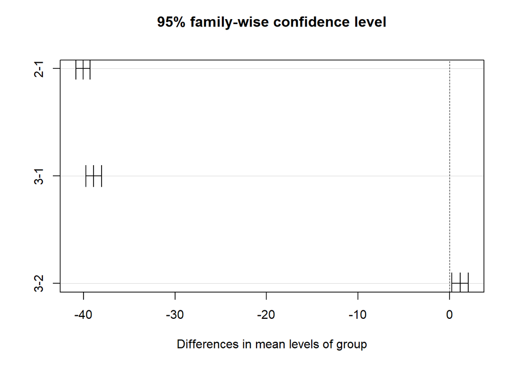

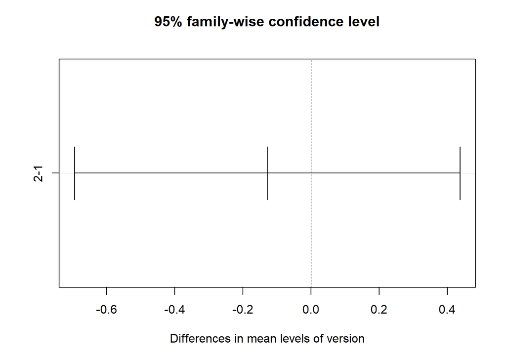

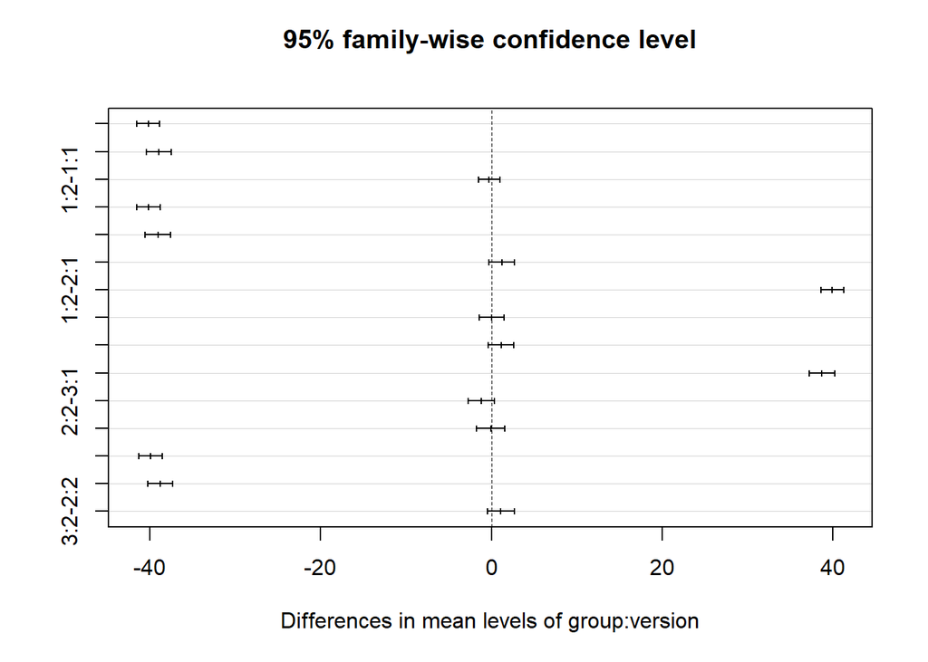

```r
plot(Tukey2)
```

Zatem możemy wnioskować z tej procedury, że grupa pierwsza ma największą średnią (co też można było zobaczyć na początku) i daje ona największą oglądalność (=największe zyski).

Jednak z analizy różnic średnich pomiędzy wersjami odtwarzacza filmów możemy stwierdzić, że:

- Różnica wynosi około -0.13 minut, co wskazuje na to iż nie ma istotnej różnicy w średnim czasie oglądania między wersjami odtwarzacza ($p-value>0.05$).

Również jasno widać z analizy interakcji grup i wersji, że:

Dla tylko grupy 1: zmiana wersji odtwarzacza nie miała istotnego wpływu na czas oglądania w tej grupie wiekowej. Różnica statystycznie nieistotna oraz $p-value$ jest bliskie 1.

Dla tylko grupy 2: zmiana wersji odtwarzacza nie miała istotnego wpływu na czas oglądania w tej grupie wiekowej. Różnica statystycznie nieistotna oraz $p-value$ jest bliskie 1.

Dla tylko grupy 3: zmiana wersji odtwarzacza nie miała istotnego wpływu na czas oglądania w tej grupie wiekowej. Różnica statystycznie nieistotna oraz $p-value$ jest bliskie 1.

### Wykresy:

Na potwierdzenie naszych wniosków, wywołamy wykresy potwierdzające naszą wcześniejszą konkluzje oraz powyższą odpowiedź:

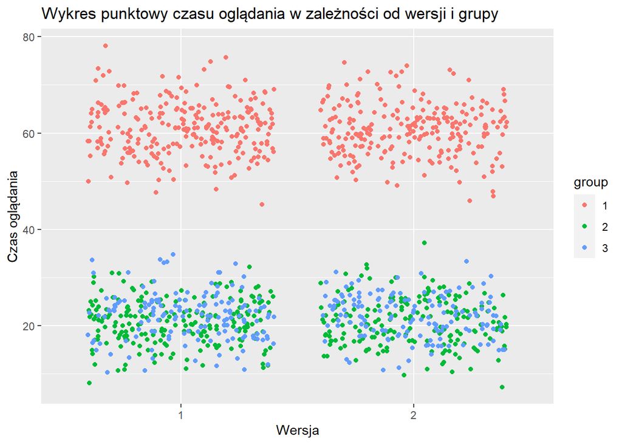

```r
ggplot(player1, aes(x=version, y= time)) + geom_point(aes(color=group), position='jitter') + labs(title = 'Wykres punktowy czasu oglądania w zależności od wersji i grupy', x='Wersja', y='Czas oglądania')
```

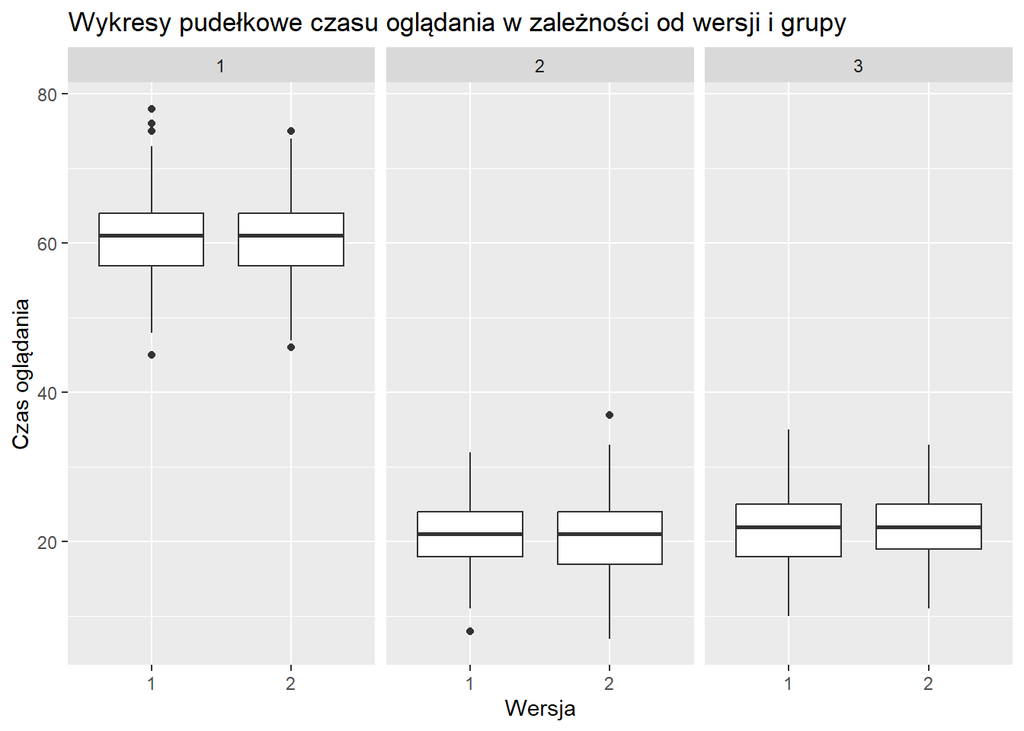

```r
ggplot(player1, aes(x=version, y=time)) + geom_boxplot() + facet_wrap(~group) + labs(title = "Wykresy pudełkowe czasu oglądania w zależności od wersji i grupy", x='Wersja', y='Czas oglądania')
```

Gdybyśmy mieli pytanie o to, czy grupa 1 (dzieci) wpływa na największą oglądalność, moglibyśmy odpowiedzieć pozytywnie. Jednak to nie jest odpowiedź na nasze pytanie. Z tego wykresu nie jesteśmy w stanie stwierdzić, czy nowy odtwarzacz do filmów wpływa na to, że największą oglądalność spodziewamy się u dzieci (zwiększenie średniej w porównaniu do starego odtwarzacza)

Zobaczmy zatem na wykres pomiędzy interakcjami między $group$ a $version$:

```r
player1
```

| group | time | version |
| --- | --- | --- |
| 1 | 65 | 1 |
| 1 | 60 | 2 |
| 1 | 53 | 1 |
| 1 | 65 | 1 |
| 1 | 64 | 1 |
| 1 | 65 | 1 |
| 1 | 64 | 2 |
| 1 | 59 | 1 |
| 1 | 58 | 1 |
| 1 | 63 | 1 |

[output cut: 1190 more lines]

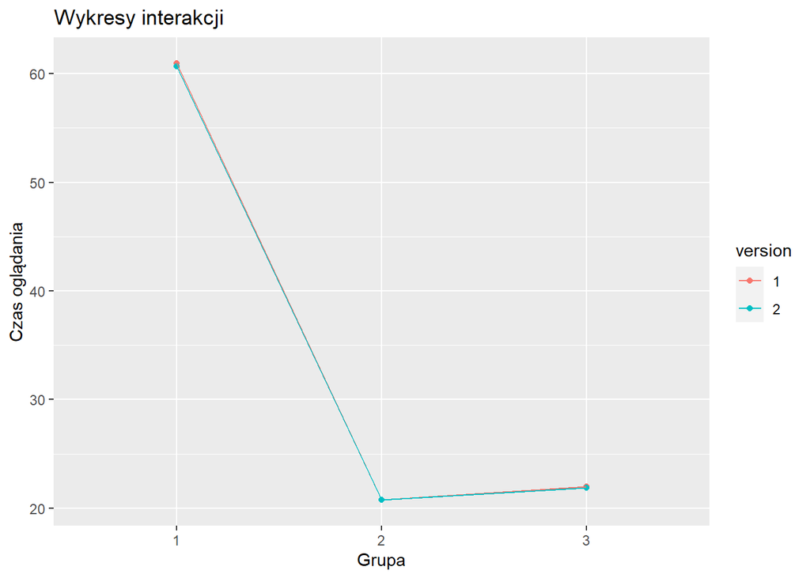

```r
ggplot(player1, aes(x=group, y=time, color=version, group=version)) +
  stat_summary(fun=, geom = 'point') +
  stat_summary(fun=, geom='line') +
  labs(title = "Wykresy interakcji", x='Grupa', y='Czas oglądania')
```

## Podsumowanie:

Wykresy interakcji dla odtwarzacza nr. 1, oraz dla odtwarzacza nr. 2 nakładają się na siebie. Zatem wprowadzenie nowej wersji odtwarzacza nie podniosło oglądalności, a co za tym idzie, inżynierowie się mylili. Nowa wersja odtwarzacza na grupe dzieci była nietrafiona. Nie podniosło to oglądalności.

## Założenia dla Dwuczynnikowej ANOVA:

1. Próby wewnątrz grup mają rozkład normalny. Możemy to zbadać za pomocą testu Shapiro-Wilka oraz histogramów:

```r
SWT11 <- shapiro.test(player1$time[player1$group == 1][player1$version == 1])
SWT21 <- shapiro.test(player1$time[player1$group == 2][player1$version == 1])
SWT31 <- shapiro.test(player1$time[player1$group == 3][player1$version == 1])
SWT12 <- shapiro.test(player1$time[player1$group == 1][player1$version == 2])
SWT22 <- shapiro.test(player1$time[player1$group == 2][player1$version == 2])
SWT32 <- shapiro.test(player1$time[player1$group == 3][player1$version == 2])
SWT11
```

```
##
##  Shapiro-Wilk normality test
##
## data:  player1$time[player1$group == 1][player1$version == 1]
## W = 0.99456, p-value = 0.5025
```

```r
SWT21
```

```
##
##  Shapiro-Wilk normality test
##
## data:  player1$time[player1$group == 2][player1$version == 1]
## W = 0.99334, p-value = 0.4944
```

```r
SWT31
```

```
##
##  Shapiro-Wilk normality test
##
## data:  player1$time[player1$group == 3][player1$version == 1]
## W = 0.99044, p-value = 0.3656
```

```r
SWT12
```

```
##
##  Shapiro-Wilk normality test
##
## data:  player1$time[player1$group == 1][player1$version == 2]
## W = 0.99226, p-value = 0.2225
```

```r
SWT22
```

```
##
##  Shapiro-Wilk normality test
##
## data:  player1$time[player1$group == 2][player1$version == 2]
## W = 0.99269, p-value = 0.4324
```

```r
SWT32
```

```
##
##  Shapiro-Wilk normality test
##
## data:  player1$time[player1$group == 3][player1$version == 2]
## W = 0.98771, p-value = 0.2411
```

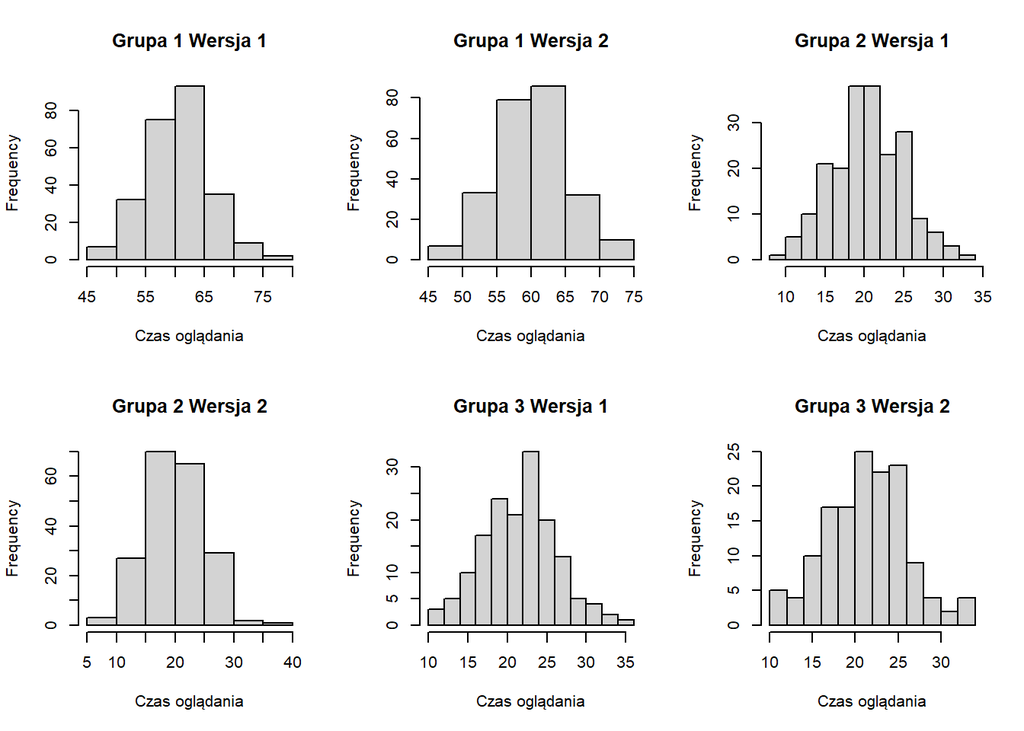

```r
groups <- unique(player1$group)
versions <- unique(player1$version)

par(mfrow=c(2,3))

for (group in groups) {
  for (version in versions) {
hist(player1$time[player1$group == group][player1$version == version], main = paste("Grupa", group, "Wersja", version), xlab = "Czas oglądania")
  }
}
```

Na podstawie wyglądu histogramów (zbliżone do rozkładu normalnego) oraz testu Shapiro-Wilka (gdzie każde $p-value>0.05$) nie mamy podstaw, aby odrzucić hipotezę o normalności danych.

2. Wszystkie próby wewnątrz grup mają stałą i jednakową wariancję.

```r
library(car)
group_ver <- interaction(player1$group, player1$version)
bartlett.test(time ~ group_ver, data = player1)
```

```
##
##  Bartlett test of homogeneity of variances
##
## data:  time by group_ver
## Bartlett's K-squared = 14.119, df = 5, p-value = 0.01487
```

```r
leveneTest(time ~ group*version, data = player1)
```

|  | Df | F value | Pr(>F) |
| --- | --- | --- | --- |
| group | 5 | 1.764201 | 0.117329 |
|  | 1194 | NA | NA |

W teście Bartletta $p-value<0.05$, co wskazuje na występowanie statystycznie istotnych różnic w wariancjach między grupami. Wyniki tego testu sugerują naruszenie założenia o jednorodności wariancji.

Z drugiej strony, test Levene’a zwraca $p-value>0.05$ , co oznacza, że nie posiadamy wystarczających dowodów do odrzucenia hipotezy zerowej zakładającej równość wariancji we wszystkich grupach. Inaczej mówiąc, możemy założyć, że wariancje są jednorodne ze względu na to, że ten test jest używany dla populacjami, które nie mają rozkładu normalnego.

3. Próby są niezależne:

Wiemy, że ANOVA jest specjalnym przypadkiem regresji liniowej dlatego możemy zbadać niezależność zbadamy za pomocą testu Durbina-Watsona na resztach modelu.

```r
library(lmtest)
niezaleznosc <- lm(time ~ group * version, data=player1)
dwtest(niezaleznosc)
```

```
##
##  Durbin-Watson test
##
## data:  niezaleznosc
## DW = 1.9899, p-value = 0.4068
## alternative hypothesis: true autocorrelation is greater than 0
```

# Zadanie 3

Na podstawie waszej renomy zarząd “Firmy na A” powierzył wam najtrudniejsze do tej pory zadanie. Tym razem nie zdali wam bezpośrednio pytania, jedynie przedstawili dane, które zbierali inżynierowie odpowiedzialni za kolejną platformę firmy - dział przechowywania danych w chmurze. Platforma działa na zasadzie udostępniania darmowego miejsca z wolnym transferem i możliwości dokupowywania coraz większej ilości miejsca za pieniądze. Istnieje również subskrypcja, zwiększająca prędkość transferu. Waszym zadaniem jest - korzystając z przedstawionych danych przekazać do działu marketingu do jakiej grupy osób najlepiej skierować reklamy, aby kupowały dodatkowe miejsce w chmurze (wniosek wysnuć za pomocą analizy wariancji i jej uogólnień).

Komentarz: Na potrzeby tego zadania przymujemy, że jeżeli osoba zajmuje dużo miejsca w swojej chmurze, to chętniej zapłaci za więcej miejsca (poprawność tego założenia samo w sobie jest ciekawym pytaniem, ale na ten moment nie zajmiemy się odpowiedzią na nie).

Opis danych:

sex - płeć

paid - czy użytkownik posiada płatną subskrypcje, 0 - nie, 1 - tak

agegrp - grupy wiekowe jak w zadaniu 2

majoritydata - rodzaj danych zajmujących największą część miejsca posiadanego przez użytkownika, 1 - wideo, 2 - obrazy, 3 - muzyka, 4 - inne

active - czy użytkownik był wgrywał jakieś pliki w przeciągu ostatnich 2 miesięcy, 0 - nie, 1 - tak

used - ilość zajętego miejsca w chmurze (w GB)

Przykład: Czy rodzaj danych przechowywanych przez użytkownika ma wpływ na ilość zajętego miejsca?

Zacznijmy od wczytania danych.

```r
zadanie3 <- as_tibble(read.csv("zadanie3.csv"))
head(zadanie3)
```

| majoritydata | used | sex | active | agegrp | paid |
| --- | --- | --- | --- | --- | --- |
| 1 | 1316 | 1 | 0 | 2 | 1 |
| 1 | 2150 | 0 | 1 | 3 | 1 |
| 1 | 2086 | 0 | 0 | 2 | 1 |
| 1 | 2098 | 1 | 0 | 3 | 1 |
| 1 | 1792 | 0 | 1 | 1 | 1 |
| 1 | 1964 | 1 | 0 | 3 | 1 |

```r
summary(zadanie3)
```

```
##   majoritydata       used             sex            active
##  Min.   :1.00   Min.   : 100.0   Min.   :0.000   Min.   :0.000
##  1st Qu.:2.00   1st Qu.: 878.8   1st Qu.:0.000   1st Qu.:0.000
##  Median :3.00   Median :1079.5   Median :0.000   Median :0.000
##  Mean   :2.52   Mean   :1205.3   Mean   :0.486   Mean   :0.464
##  3rd Qu.:3.00   3rd Qu.:1393.5   3rd Qu.:1.000   3rd Qu.:1.000
##  Max.   :4.00   Max.   :3349.0   Max.   :1.000   Max.   :1.000
##      agegrp           paid
##  Min.   :1.000   Min.   :0.0000
##  1st Qu.:1.000   1st Qu.:0.0000
##  Median :2.000   Median :0.0000
##  Mean   :2.154   Mean   :0.4624
##  3rd Qu.:3.000   3rd Qu.:1.0000
##  Max.   :3.000   Max.   :1.0000
```

Zacznijmy od wykresu pudełkowego zależności zmiennej zależnej $used$ od zmiennej $paid$

```r
zadanie3 <- zadanie3 %>% dplyr::mutate(paid = as.character(paid))
```

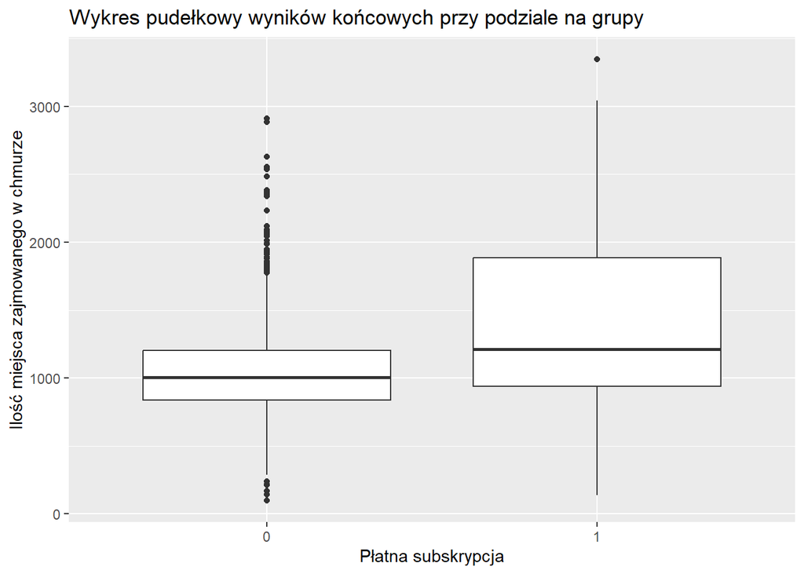

```r
ggplot(zadanie3, aes(x=paid, y=used)) + geom_boxplot() + labs(title = "Wykres pudełkowy wyników końcowych przy podziale na grupy", x='Płatna subskrypcja', y='Ilość miejsca zajmowanego w chmurze')
```

Możemy zauważyć, że użytkownicy posiadający płatną subskrypcję zajmują zdecydowanie więcej miejsca w chmurze, możemy również zobaczyć że spora część użytkowników która posiada płatną subskrypcję nie należy do grupy zajmującej większą ilość miejsca w chmurze (w porównaniu do użytkowników nie posiadających płatnej sukbskrypcji). Możemy z tego wywnioskować, że użytkownicy z płatną subskrypcją niekoniecznie w przyszłości będą potrzebować większej ilości miejsca w chmurze.

Sprawdźmy teraz jak wygląda wykres pudełkowy zależności zmiennej zależnej $used$ od zmiennej $sex$

```r
zadanie3 <- zadanie3 %>% dplyr::mutate(sex = as.character(sex))
```

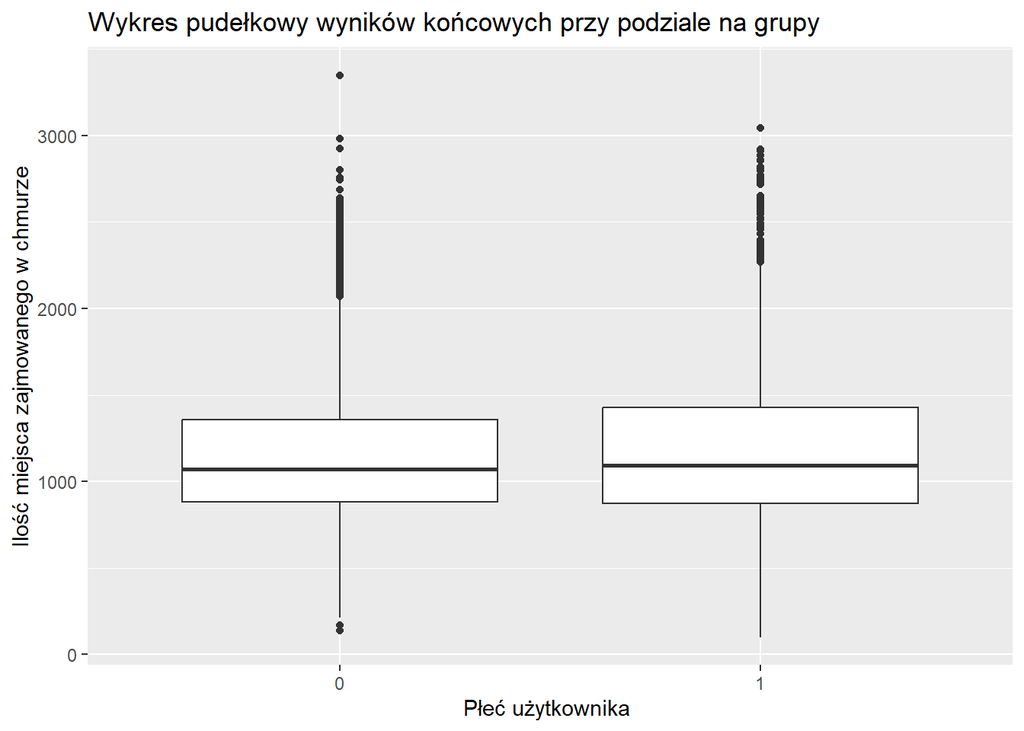

```r
ggplot(zadanie3, aes(x=sex, y=used)) + geom_boxplot() + labs(title = "Wykres pudełkowy wyników końcowych przy podziale na grupy", x='Płeć użytkownika ', y='Ilość miejsca zajmowanego w chmurze')
```

Można zobaczyć, że płeć użytkownika nie wpływa na ilość zajmowanego miejsca, dlatego nie będziemy się na tym skupiać.

Sprawdźmy jeszcze jak wygląda wykres pudełkowy zależności zmiennej $used$ względem zmiennej $agegrp$.

```r
zadanie3 <- zadanie3 %>% dplyr::mutate(agegrp = as.character(agegrp))
```

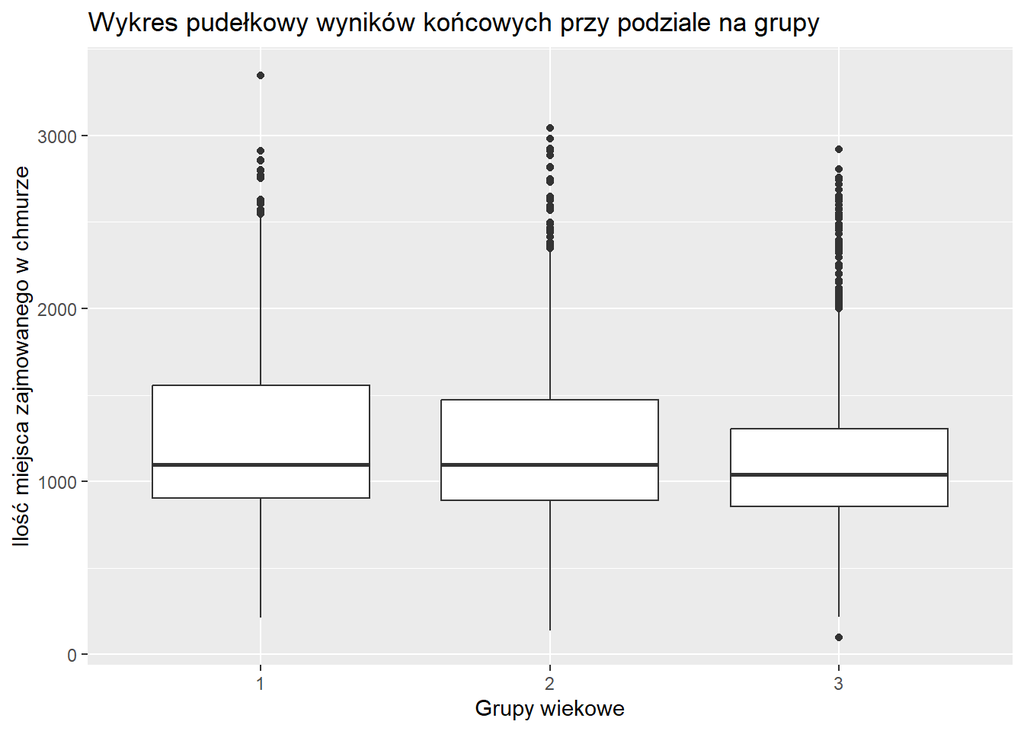

```r
ggplot(zadanie3, aes(x=agegrp, y=used)) + geom_boxplot() + labs(title = "Wykres pudełkowy wyników końcowych przy podziale na grupy", x='Grupy wiekowe', y='Ilość miejsca zajmowanego w chmurze')
```

Tutaj podobnie, jak w przypadku zmiennej $sex$, ilość zajmowanego miejsca jest podobna w każdej grupie wiekowej.

Sprawdźmy kolejną zmienną, zmienną $active$

```r
zadanie3 <- zadanie3 %>% dplyr::mutate(active = as.character(active))
```

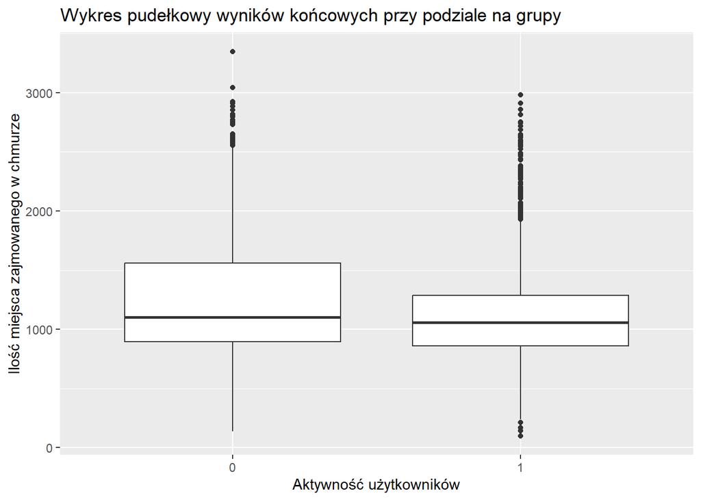

```r
ggplot(zadanie3, aes(x=active, y=used)) + geom_boxplot() + labs(title = "Wykres pudełkowy wyników końcowych przy podziale na grupy", x='Aktywność użytkowników', y='Ilość miejsca zajmowanego w chmurze')
```

W przypadku aktywności, również nie zmienia się znacząco liczba zajmowanego miejsca przez użytkowników.

Teraz zmienna $majoritydata$

```r
zadanie3 <- zadanie3 %>% dplyr::mutate(majoritydata = as.character(majoritydata))
```

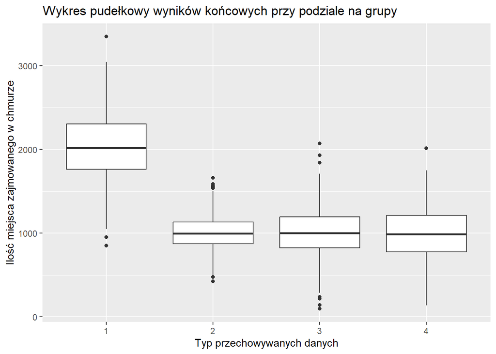

```r
ggplot(zadanie3, aes(x=majoritydata, y=used)) + geom_boxplot() + labs(title = "Wykres pudełkowy wyników końcowych przy podziale na grupy", x='Typ przechowywanych danych', y='Ilość miejsca zajmowanego w chmurze')
```

Widzimy, że pierwszy typ danych (filmy) wybija się na tle innych, co może oznaczać, że osoby które zgrywają dużą ilość filmów będą potrzebowały więcej miejsca w chmurze.

## Tworzenie modelu

Zaczynamy od jednoczynnikowej analizy wariancji, czyli sprawdzimy jak nasza zmienna $used$ wpływa na zmienną $majoritydata$

Narysujmy sobie jak wygląda ilość zajmowanego miejsca na dysku w zależności od typu danych jakie posiada nasz użytkownik.

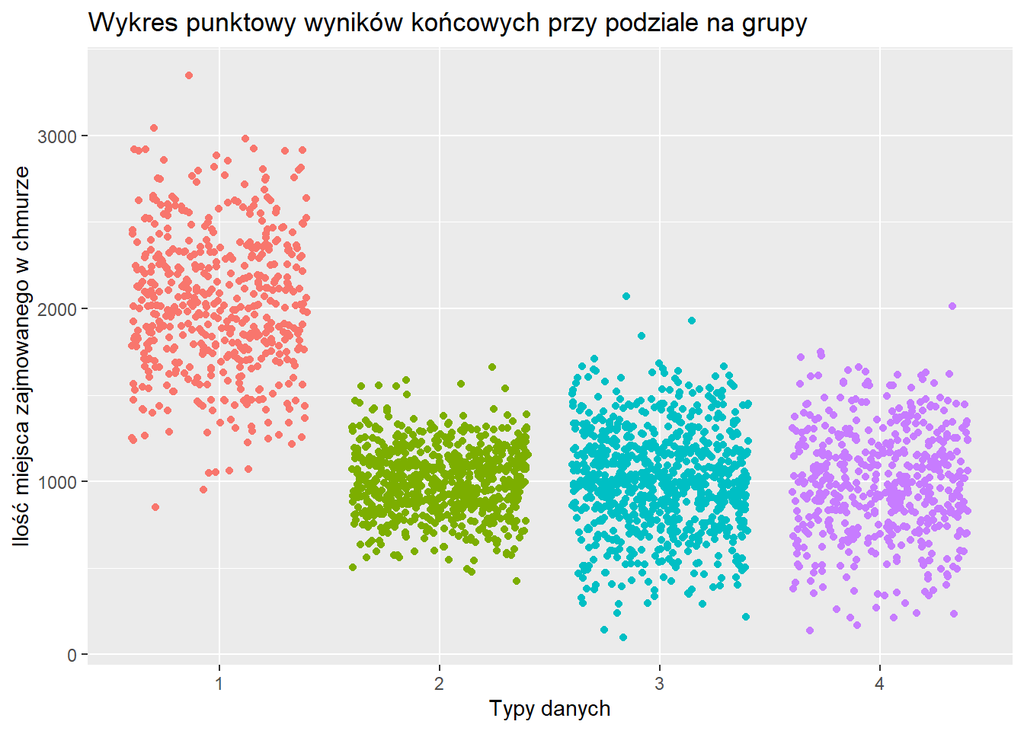

```r
ggplot(zadanie3, aes(x=majoritydata, y=used)) + geom_point(aes(color=majoritydata), position='jitter') + labs(title = 'Wykres punktowy wyników końcowych przy podziale na grupy', x='Typy danych', y='Ilość miejsca zajmowanego w chmurze') + theme(legend.position = 'none')
```

## Założenia modelu

Sprawdźmy czy grupy należą do rozkładu normalnego

```r
zadanie3 %>% group_by (majoritydata) %>% summarise(pval = shapiro.test(used)$p) %>% print()
```

```
## # A tibble: 4 × 2
##   majoritydata  pval
##   <chr>        <dbl>
## 1 1            0.861
## 2 2            0.615
## 3 3            0.646
## 4 4            0.712
```

Możemy zauważyć, że założenie jest spełnione, nie mamy żadnych podstaw do odrzucenia hipotezy zerowej. Nasze grupy faktycznie pochodzą z rozkładu normalnego.

Sprawdzimy, czy wariancja jest równa na poziomie istotności grup.

```r
bartlett.test(used ~ majoritydata, data = zadanie3)
```

```
##
##  Bartlett test of homogeneity of variances
##
## data:  used by majoritydata
## Bartlett's K-squared = 293.4, df = 3, p-value < 2.2e-16
```

Wartość $p-value < 2.2e-16$ jest mniejsza od $0.05$, co oznacza, że to założenie nie jest spełnione. Wprowadźmy zatem poprawkę Welscha.

```r
oneway.test(used~majoritydata, data = zadanie3)
```

```
##
##  One-way analysis of means (not assuming equal variances)
##
## data:  used and majoritydata
## F = 1000.8, num df = 3.0, denom df = 1198.9, p-value < 2.2e-16
```

Widzimy, że istnieje istotna statystycznie różnica w ilości zajmowanego miejsca w chmurze pomiędzy conajmniej jedną parą grup. Wartość $p-value < 0.05$ możemy z tego wywnioskować, że odrzucamy hipotezę zerową, która zakładała brak istotnych różnic między poszczególnymi grupami. Widzimy w takim razie, że rodzaj danych zajmujących najwięcej miejsca w chmurze ma wpływ na ilość zajmowanego przez użytkownika miejsca.

Wartość statytsyki $F= 1000.8$ jest duża, może to oznaczać, że jest różnica między grupami.

Sprawdzimy teraz czy grupy są równoliczne .

```r
zadanie3 %>% group_by (majoritydata) %>% count() %>% print()
```

```
## # A tibble: 4 × 2
## # Groups:   majoritydata [4]
##   majoritydata     n
##   <chr>        <int>
## 1 1              500
## 2 2              700
## 3 3              800
## 4 4              500
```

Możemy zobaczyć, że niektóre grupy są równoliczne, najliczniejszym typem danych jest muzyka, natomiast najmniej jest filmów video i innych.

Kolejnym punktem będzie wykonanie Testu Gamesa - Howella

```r
ghTest1 <- rstatix::games_howell_test(used ~ majoritydata, data = zadanie3)
ghTest1 <- ghTest1 %>% dplyr::mutate(gr_label = paste(group1,group2, sep='-')) %>% dplyr::mutate(order = row_number())
ghTest1
```

| .y. | group1 | group2 | estimate | conf.low | conf.high | p.adj | p.adj.signif | gr_label | order |
| --- | --- | --- | --- | --- | --- | --- | --- | --- | --- |
| used | 1 | 2 | -1028.002286 | -1077.97789 | -978.02668 | 0.00e+00 | **** | 1-2 | 1 |
| used | 1 | 3 | -1024.871750 | -1078.25008 | -971.49342 | 4.46e-13 | **** | 1-3 | 2 |
| used | 1 | 4 | -1036.682000 | -1095.44504 | -977.91896 | 2.62e-13 | **** | 1-4 | 3 |
| used | 2 | 3 | 3.130536 | -29.89713 | 36.15820 | 9.95e-01 | ns | 2-3 | 4 |
| used | 2 | 4 | -8.679714 | -49.89447 | 32.53504 | 9.49e-01 | ns | 2-4 | 5 |
| used | 3 | 4 | -11.810250 | -57.09632 | 33.47582 | 9.08e-01 | ns | 3-4 | 6 |

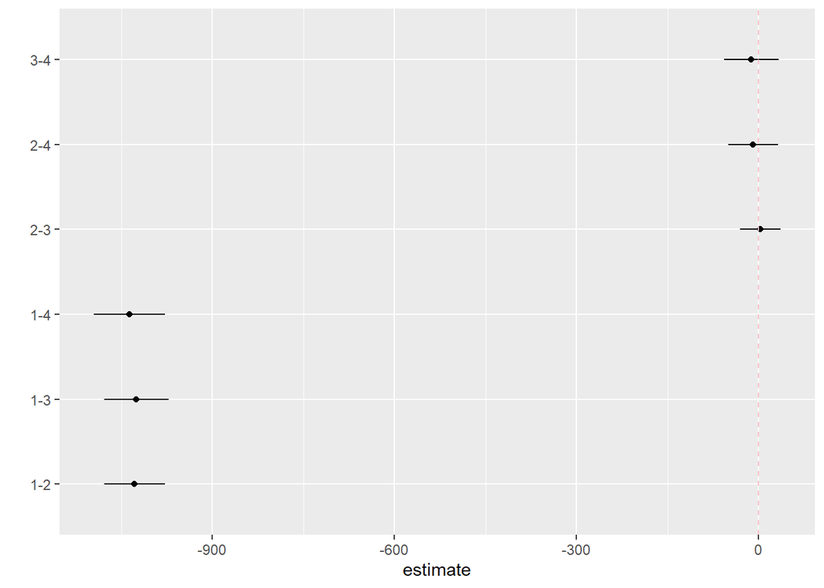

```r
ggplot(ghTest1, aes(x=estimate, y = order)) +  geom_linerange(aes(xmin = conf.low, xmax = conf.high)) + geom_point() + scale_y_discrete(name = '', limits = as.factor(ghTest1$order), labels = ghTest1$gr_label) + geom_vline(xintercept = 0, color = 'pink', linetype = 'dashed')
```

Możemy zoabczyć zależność między grupą pierwszą a pozostałymi grupami, co oznacza, że najlepszym pomysłem będzie kierowanie oferty do osób przechowujących na chmurze filmy.

Upewnijmy się jeszcze, za pomocą nieparametrycznego testu Kruskala.

```r
kruskal.test(used~majoritydata, data=zadanie3)
```

```
##
##  Kruskal-Wallis rank sum test
##
## data:  used by majoritydata
## Kruskal-Wallis chi-squared = 1126.3, df = 3, p-value < 2.2e-16
```

Widzimy, że jest duża zależność między grupami, spróbujmy to zbadać.

```r
zadanie3 <- zadanie3 %>% dplyr::mutate(majoritydata = as.character(majoritydata))
```

```r
library(FSA)
FSA::dunnTest(used~majoritydata, data=zadanie3)
```

```
##   Comparison          Z       P.unadj         P.adj
## 1      1 - 2 28.7740538 4.530942e-182 2.265471e-181
## 2      1 - 3 29.1657490 5.275096e-187 3.165057e-186
## 3      2 - 3 -0.4276417  6.689120e-01  1.000000e+00
## 4      1 - 4 26.7516423 1.181634e-157 4.726536e-157
## 5      2 - 4  0.1210223  9.036734e-01  9.036734e-01
## 6      3 - 4  0.5125334  6.082777e-01  1.000000e+00
```

Widzimy, że ze wzrostem wartości pojawia się większa różnica między grupami.

Porównanie między grupami $1$ a $2$ oraz $1$ a $3$: Wynik statystyki $Z$ był bardzo duży w obu przypadkach, co sugeruje znaczące różnice między tymi grupami. Prawdopodobieństwo uzyskania tak dużej różnicy, gdyby faktycznie nie było żadnej różnicy między grupami, było praktycznie równe zeru.

Natomiast porównanie między grupami $2$ a $3$, $2$ a $4$ oraz $3$ a $4$ nie wykazało istotnych różnic, ponieważ wartości Z były bliskie zeru lub wyniki $p-wartości$ były większe od ustalonego poziomu istotności $ 0.05$ .

Dodatkowo, test nieparametryczny Kruskalla i test post-hoc Dunna potwierdzają te obserwacje, które wykazał wcześniejszy test, co potwierdza istotność różnic między grupami, gdy P.adj jest mniejsze niż ustalony poziom istotności.

## Podsumowanie

Na podstawie analizy danych wynika, że użytkownicy, którzy przesyłają głównie pliki wideo, zajmują najwięcej miejsca w chmurze. To oznacza, że ich dostępna przestrzeń może szybciej się wyczerpać, co może skłonić ich do zakupu dodatkowej przestrzeni. Dlatego dział marketingu powinien kierować reklamy właśnie do tych użytkowników, zachęcając ich do rozszerzenia swojej przestrzeni w chmurze.